# Exploratory Data Analysis of Aadhaar Enrolment Data

# Top 10 Districts by Enrollment

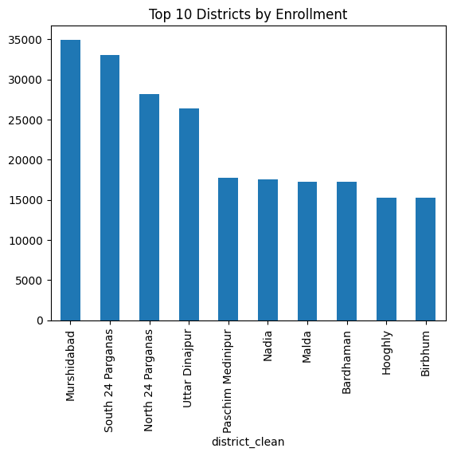

```python
top_districts = df.groupby('district_clean')['total_enrollment'] \
                  .sum().sort_values(ascending=False).head(10)

top_districts.plot(kind='bar')
plt.title('Top 10 Districts by Enrollment')
plt.show()
```

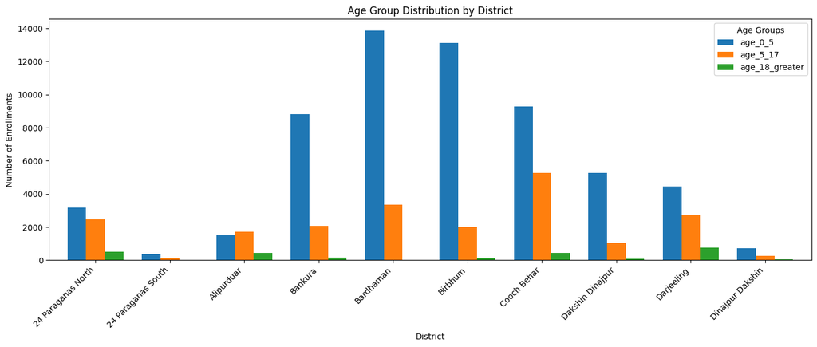

```python
import matplotlib.pyplot as plt

district_age = df.groupby('district_clean')[
    ['age_0_5','age_5_17','age_18_greater']
].sum().head(10)

ax = district_age.plot(
    kind='bar',
    stacked=False,      # important → no overlap
    figsize=(14,6),
    width=0.75
)

plt.title('Age Group Distribution by District')
plt.xlabel('District')
plt.ylabel('Number of Enrollments')
plt.xticks(rotation=45, ha='right')
plt.legend(title='Age Groups')
plt.tight_layout()
plt.show()
```

# 📊 Enrollment Variability Across Districts

This bar chart highlights the top 10 districts with the highest standard deviation in total  
enrollment, indicating significant variability over time. High volatility suggests inconsistent  
enrollment patterns, possibly due to seasonal drives, migration, or administrative factors.

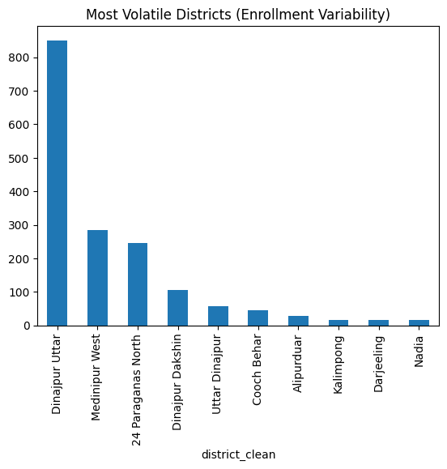

```python
district_std = df.groupby('district_clean')['total_enrollment'].std()

district_std.sort_values(ascending=False).head(10).plot(kind='bar')
plt.title('Most Volatile Districts (Enrollment Variability)')
plt.show()
```

# 📌 District-wise Enrollment Ranking Analysis

**This analysis ranks districts based on their total Aadhaar enrollment over the entire study period.**

```python
district_rank = df.groupby('district_clean')['total_enrollment'].sum() \
                  .rank(ascending=False)

district_rank.sort_values().head(10)
```

```
district_clean
Murshidabad           1.0
South 24 Parganas     2.0
North 24 Parganas     3.0
Uttar Dinajpur        4.0
Paschim Medinipur     5.0
Nadia                 6.0
Malda                 7.0
Bardhaman             8.0
Hooghly               9.0
Birbhum              10.0
Name: total_enrollment, dtype: float64
```

We performed univariate, bivariate, and multivariate analysis to study  
enrollment distribution across states, districts, and age groups. Advanced analysis included  
district-level volatility, age composition, time-based trends, and flag-based segmentation to uncover hidden patterns.

# Maharashtra

```python
# Extracting rows where state is Maharashtra
df_Maharashtra= df[df['state_clean']=='Maharashtra']
```

```python
# Total unique districts in
df_Maharashtra['district'].nunique()
```

```
53
```

```python
# Same District have more than one spelling so we have to map them
df_Maharashtra['district'].unique()
```

```
array(['Aurangabad', 'Parbhani', 'Thane', 'Nanded', 'Nagpur', 'Jalgaon',
       'Hingoli', 'Ahmadnagar', 'Palghar', 'Satara', 'Raigad',
       'Mumbai Suburban', 'Nandurbar', 'Beed', 'Chandrapur', 'Solapur',
       'Pune', 'Latur', 'Nashik', 'Yavatmal', 'Dhule', 'Washim', 'Sangli',
       'Buldhana', 'Amravati', 'Ahmednagar', 'Mumbai', 'Akola',
       'Osmanabad', 'Ahmed Nagar', 'Bhandara', 'Buldana',
       'Chhatrapati Sambhajinagar', 'Gadchiroli', 'Gondiya', 'Jalna',
       'Kolhapur', 'Mumbai City', 'Raigarh', 'Ratnagiri', 'Sindhudurg',
       'Wardha', 'Chatrapati Sambhaji Nagar', 'Mumbai( Sub Urban )',
       'Nandurbar *', 'Bid', 'Gondiya *', 'Dharashiv', 'Gondia',
       'Washim *', 'Raigarh(MH)', 'Hingoli *', 'Ahilyanagar'],
      dtype=object)
```

```python
df_Maharashtra['district_clean'] = (
    df_Maharashtra['district']
    .str.lower()
    .str.strip()
    .str.replace(r'\*', '', regex=True)
    .str.replace(r'\(.*?\)', '', regex=True)
    .str.replace(r'[^a-z\s]', '', regex=True)
)
```

# Mapping District

```python
## District mapping Maharashtra
mh_district_standard_map = {
    "aurangabad": "Chhatrapati Sambhajinagar",
    "chhatrapati sambhajinagar": "Chhatrapati Sambhajinagar",
    "chatrapati sambhaji nagar": "Chhatrapati Sambhajinagar",

    "ahilyanagar": "Ahmednagar",
    "ahmadnagar": "Ahmednagar",
    "ahmednagar": "Ahmednagar",
    "ahmed nagar": "Ahmednagar",

    "bid": "Beed",
    "beed": "Beed",

    "buldana": "Buldhana",
    "buldhana": "Buldhana",

    "osmanabad": "Dharashiv",
    "dharashiv": "Dharashiv",

    "gondiya": "Gondia",
    "gondiya *": "Gondia",
    "gondia": "Gondia",

    "raigarh(mh)": "Raigad",
    "raigad": "Raigad",

    "nandurbar *": "Nandurbar",
    "nandurbar": "Nandurbar",

    "hingoli *": "Hingoli",
    "hingoli": "Hingoli",

    "washim *": "Washim",
    "washim": "Washim",

    "mumbai suburban": "Mumbai Suburban",
    "mumbai( sub urban )": "Mumbai Suburban",

    "mumbai": "Mumbai City",
    "mumbai city": "Mumbai City"
}
```

```python
df['district_clean'] = (
    df['district']
    .apply(clean_name)
    .map(mh_district_standard_map)
    .fillna(df_Maharashtra['district'])
)
```

```python
## Remaining unmapped
df[df['district_clean'].isna()]['district'].unique()
# count check
df['district_clean'].nunique()
```

```
40
```

```python
df_Maharashtra = df[df['state_clean']=='Maharashtra']
df_Maharashtra
```

|  | date | state | district | pincode | age_0_5 | age_5_17 | age_18_greater | year | month | month_name | state_clean | total_enrollment | district_clean |
| --- | --- | --- | --- | --- | --- | --- | --- | --- | --- | --- | --- | --- | --- |
| 12 | 2025-03-09 | Maharashtra | Aurangabad | 431001 | 42 | 46 | 12 | 2025 | 3 | Mar | Maharashtra | 100 | Chhatrapati Sambhajinagar |
| 43 | 2025-03-15 | Maharashtra | Parbhani | 431401 | 17 | 14 | 37 | 2025 | 3 | Mar | Maharashtra | 68 | Parbhani |
| 67 | 2025-03-20 | Maharashtra | Thane | 421503 | 19 | 13 | 15 | 2025 | 3 | Mar | Maharashtra | 47 | Thane |
| 78 | 2025-03-20 | Maharashtra | Aurangabad | 431001 | 134 | 38 | 18 | 2025 | 3 | Mar | Maharashtra | 190 | Chhatrapati Sambhajinagar |
| 151 | 2025-03-27 | Maharashtra | Aurangabad | 431001 | 20 | 19 | 16 | 2025 | 3 | Mar | Maharashtra | 55 | Chhatrapati Sambhajinagar |
| ... | ... | ... | ... | ... | ... | ... | ... | ... | ... | ... | ... | ... | ... |
| 1004434 | 2025-12-31 | Maharashtra | Yavatmal | 445105 | 2 | 1 | 0 | 2025 | 12 | Dec | Maharashtra | 3 | Yavatmal |
| 1004435 | 2025-12-31 | Maharashtra | Yavatmal | 445109 | 6 | 1 | 0 | 2025 | 12 | Dec | Maharashtra | 7 | Yavatmal |
| 1004436 | 2025-12-31 | Maharashtra | Yavatmal | 445205 | 4 | 2 | 0 | 2025 | 12 | Dec | Maharashtra | 6 | Yavatmal |
| 1004437 | 2025-12-31 | Maharashtra | Yavatmal | 445211 | 1 | 0 | 0 | 2025 | 12 | Dec | Maharashtra | 1 | Yavatmal |
| 1004438 | 2025-12-31 | Maharashtra | Yavatmal | 445401 | 2 | 1 | 0 | 2025 | 12 | Dec | Maharashtra | 3 | Yavatmal |

75531 rows × 13 columns

```python
# Check Bihar-specific unmapped districts
df_Maharashtra_unmapped = df_Maharashtra[df_Maharashtra['district_clean'].isna()]
print(f"Unmapped Maharashtra districts count: {len(df_Maharashtra_unmapped)}")
df_Maharashtra_unmapped['district'].unique()
```

```
Unmapped Maharashtra districts count: 0
```

```
array([], dtype=object)
```

```python
# Final unique districts in Maharashtra after cleaning
df_Maharashtra['district_clean'].unique()
```

```
array(['Chhatrapati Sambhajinagar', 'Parbhani', 'Thane', 'Nanded',
       'Nagpur', 'Jalgaon', 'Hingoli', 'Ahmednagar', 'Palghar', 'Satara',
       'Raigad', 'Mumbai Suburban', 'Nandurbar', 'Beed', 'Chandrapur',
       'Solapur', 'Pune', 'Latur', 'Nashik', 'Yavatmal', 'Dhule',
       'Washim', 'Sangli', 'Buldhana', 'Amravati', 'Mumbai City', 'Akola',
       'Dharashiv', 'Bhandara', 'Gadchiroli', 'Gondia', 'Jalna',
       'Kolhapur', 'Raigarh', 'Ratnagiri', 'Sindhudurg', 'Wardha',
       'Chatrapati Sambhaji Nagar', 'Mumbai( Sub Urban )', 'Raigarh(MH)'],
      dtype=object)
```

```python
# Total unique districts in Maharashtra after cleaning
df_Maharashtra['district_clean'].nunique()
```

```
40
```

```python
# unique pincodes in Maharashtra
df_Maharashtra['pincode'].nunique()
```

```
1580
```

```python
# Check unique pincodes per district in Maharashtra
pincode_check = df_Maharashtra.groupby('district_clean')['pincode'].nunique().reset_index(name='unique_pincodes')
pincode_check
```

|  | district_clean | unique_pincodes |
| --- | --- | --- |
| 0 | Ahmednagar | 90 |
| 1 | Akola | 29 |
| 2 | Amravati | 42 |
| 3 | Beed | 28 |
| 4 | Bhandara | 21 |
| 5 | Buldhana | 32 |
| 6 | Chandrapur | 33 |
| 7 | Chatrapati Sambhaji Nagar | 3 |
| 8 | Chhatrapati Sambhajinagar | 44 |
| 9 | Dharashiv | 28 |
| 10 | Dhule | 29 |
| 11 | Gadchiroli | 15 |
| 12 | Gondia | 14 |
| 13 | Hingoli | 14 |
| 14 | Jalgaon | 62 |
| 15 | Jalna | 26 |
| 16 | Kolhapur | 78 |
| 17 | Latur | 24 |
| 18 | Mumbai City | 109 |
| 19 | Mumbai Suburban | 55 |
| 20 | Mumbai( Sub Urban ) | 47 |
| 21 | Nagpur | 67 |
| 22 | Nanded | 44 |
| 23 | Nandurbar | 20 |
| 24 | Nashik | 76 |
| 25 | Palghar | 37 |
| 26 | Parbhani | 19 |
| 27 | Pune | 147 |
| 28 | Raigad | 58 |
| 29 | Raigarh | 62 |
| 30 | Raigarh(MH) | 14 |
| 31 | Ratnagiri | 72 |
| 32 | Sangli | 66 |
| 33 | Satara | 79 |
| 34 | Sindhudurg | 52 |
| 35 | Solapur | 71 |
| 36 | Thane | 93 |
| 37 | Wardha | 17 |
| 38 | Washim | 14 |
| 39 | Yavatmal | 33 |

```python
# Pincode associated with multiple districts in Maharashtra
pin_district_count = (
    df_Maharashtra.groupby('pincode')['district_clean']
    .nunique()
    .reset_index(name='district_count')
)
```

```python
# Extract problematic pincodes (associated with >1 district)
problem_pins = pin_district_count[
    pin_district_count['district_count'] > 1
]
```

```python
problem_pins
```

|  | pincode | district_count |
| --- | --- | --- |
| 0 | 400001 | 2 |
| 11 | 400012 | 2 |
| 22 | 400024 | 3 |
| 27 | 400029 | 2 |
| 31 | 400033 | 2 |
| ... | ... | ... |
| 1472 | 444108 | 2 |
| 1474 | 444110 | 2 |
| 1494 | 444405 | 2 |
| 1497 | 444501 | 2 |
| 1499 | 444503 | 2 |

213 rows × 2 columns

```python
# Get all records with problematic pincodes(flagged records)
df_flagged = df_Maharashtra.merge(
    problem_pins[['pincode']],
    on='pincode',
    how='inner'
)
```

```python
df_flagged
```

|  | date | state | district | pincode | age_0_5 | age_5_17 | age_18_greater | year | month | month_name | state_clean | total_enrollment | district_clean |
| --- | --- | --- | --- | --- | --- | --- | --- | --- | --- | --- | --- | --- | --- |
| 0 | 2025-03-09 | Maharashtra | Aurangabad | 431001 | 42 | 46 | 12 | 2025 | 3 | Mar | Maharashtra | 100 | Chhatrapati Sambhajinagar |
| 1 | 2025-03-20 | Maharashtra | Aurangabad | 431001 | 134 | 38 | 18 | 2025 | 3 | Mar | Maharashtra | 190 | Chhatrapati Sambhajinagar |
| 2 | 2025-03-27 | Maharashtra | Aurangabad | 431001 | 20 | 19 | 16 | 2025 | 3 | Mar | Maharashtra | 55 | Chhatrapati Sambhajinagar |
| 3 | 2025-04-01 | Maharashtra | Hingoli | 431512 | 243 | 22 | 33 | 2025 | 4 | Apr | Maharashtra | 298 | Hingoli |
| 4 | 2025-04-01 | Maharashtra | Palghar | 401209 | 174 | 90 | 16 | 2025 | 4 | Apr | Maharashtra | 280 | Palghar |
| ... | ... | ... | ... | ... | ... | ... | ... | ... | ... | ... | ... | ... | ... |
| 16261 | 2025-12-31 | Maharashtra | Thane | 401209 | 4 | 5 | 0 | 2025 | 12 | Dec | Maharashtra | 9 | Thane |
| 16262 | 2025-12-31 | Maharashtra | Thane | 401302 | 0 | 1 | 0 | 2025 | 12 | Dec | Maharashtra | 1 | Thane |
| 16263 | 2025-12-31 | Maharashtra | Thane | 401404 | 1 | 0 | 0 | 2025 | 12 | Dec | Maharashtra | 1 | Thane |
| 16264 | 2025-12-31 | Maharashtra | Thane | 421303 | 2 | 0 | 0 | 2025 | 12 | Dec | Maharashtra | 2 | Thane |
| 16265 | 2025-12-31 | Maharashtra | Wardha | 442302 | 3 | 0 | 0 | 2025 | 12 | Dec | Maharashtra | 3 | Wardha |

16266 rows × 13 columns

```python
# Summary of flagged records by district and pincode(for review)
flagged_pincode=df_flagged.groupby(['district_clean','pincode'])[['age_0_5','age_5_17','age_18_greater']].sum().reset_index()
# flagged_pincode.to_excel('flagged_pincode_domain.xlsx')
```

```python
# Add total enrollment column to flagged_pincode
flagged_pincode['total_enrollment']=flagged_pincode['age_0_5']+flagged_pincode['age_5_17']+flagged_pincode['age_18_greater']
flagged_pincode
```

|  | district_clean | pincode | age_0_5 | age_5_17 | age_18_greater | total_enrollment |
| --- | --- | --- | --- | --- | --- | --- |
| 0 | Ahmednagar | 400037 | 2 | 2 | 0 | 4 |
| 1 | Ahmednagar | 412210 | 32 | 5 | 0 | 37 |
| 2 | Akola | 444105 | 3 | 0 | 0 | 3 |
| 3 | Akola | 444107 | 151 | 20 | 0 | 171 |
| 4 | Akola | 444108 | 177 | 32 | 1 | 210 |
| ... | ... | ... | ... | ... | ... | ... |
| 492 | Washim | 444105 | 352 | 28 | 5 | 385 |
| 493 | Washim | 444107 | 32 | 3 | 0 | 35 |
| 494 | Washim | 444110 | 77 | 5 | 4 | 86 |
| 495 | Washim | 444405 | 3 | 1 | 0 | 4 |
| 496 | Washim | 444503 | 262 | 20 | 4 | 286 |

497 rows × 6 columns

```python
idx = flagged_pincode.groupby('pincode')['total_enrollment'].idxmax()
df_filtered = flagged_pincode.loc[idx]
df_filtered
```

|  | district_clean | pincode | age_0_5 | age_5_17 | age_18_greater | total_enrollment |
| --- | --- | --- | --- | --- | --- | --- |
| 77 | Mumbai City | 400001 | 43 | 13 | 6 | 62 |
| 78 | Mumbai City | 400012 | 245 | 21 | 9 | 275 |
| 154 | Mumbai Suburban | 400024 | 51 | 12 | 2 | 65 |
| 80 | Mumbai City | 400029 | 39 | 9 | 0 | 48 |
| 81 | Mumbai City | 400033 | 128 | 26 | 2 | 156 |
| ... | ... | ... | ... | ... | ... | ... |
| 4 | Akola | 444108 | 177 | 32 | 1 | 210 |
| 494 | Washim | 444110 | 77 | 5 | 4 | 86 |
| 6 | Akola | 444405 | 55 | 2 | 0 | 57 |
| 7 | Akola | 444501 | 252 | 23 | 3 | 278 |
| 496 | Washim | 444503 | 262 | 20 | 4 | 286 |

213 rows × 6 columns

```python
# Creating a flag for pincodes associated with multiple districts
df_Maharashtra['pin_multi_district_flag']=(
    df_Maharashtra.groupby('pincode')['district_clean']
    .transform('nunique')>1
)
```

```python
# Creating a flag for pincodes associated with multiple districts
pin_district_map= (
    df_Maharashtra[df_Maharashtra['pin_multi_district_flag']]
    .groupby('pincode')['district_clean']  # noqa: SC100
    .unique()
    .reset_index()
)
```

```python
## monthly enrolment check
df_Maharashtra['month'] = df_Maharashtra['date'].dt.month.astype(str).str.zfill(2)
df_Maharashtra
```

|  | date | state | district | pincode | age_0_5 | age_5_17 | age_18_greater | year | month | month_name | state_clean | total_enrollment | district_clean | pin_multi_district_flag |
| --- | --- | --- | --- | --- | --- | --- | --- | --- | --- | --- | --- | --- | --- | --- |
| 12 | 2025-03-09 | Maharashtra | Aurangabad | 431001 | 42 | 46 | 12 | 2025 | 03 | Mar | Maharashtra | 100 | Chhatrapati Sambhajinagar | True |
| 43 | 2025-03-15 | Maharashtra | Parbhani | 431401 | 17 | 14 | 37 | 2025 | 03 | Mar | Maharashtra | 68 | Parbhani | False |
| 67 | 2025-03-20 | Maharashtra | Thane | 421503 | 19 | 13 | 15 | 2025 | 03 | Mar | Maharashtra | 47 | Thane | False |
| 78 | 2025-03-20 | Maharashtra | Aurangabad | 431001 | 134 | 38 | 18 | 2025 | 03 | Mar | Maharashtra | 190 | Chhatrapati Sambhajinagar | True |
| 151 | 2025-03-27 | Maharashtra | Aurangabad | 431001 | 20 | 19 | 16 | 2025 | 03 | Mar | Maharashtra | 55 | Chhatrapati Sambhajinagar | True |
| ... | ... | ... | ... | ... | ... | ... | ... | ... | ... | ... | ... | ... | ... | ... |
| 1004434 | 2025-12-31 | Maharashtra | Yavatmal | 445105 | 2 | 1 | 0 | 2025 | 12 | Dec | Maharashtra | 3 | Yavatmal | False |
| 1004435 | 2025-12-31 | Maharashtra | Yavatmal | 445109 | 6 | 1 | 0 | 2025 | 12 | Dec | Maharashtra | 7 | Yavatmal | False |
| 1004436 | 2025-12-31 | Maharashtra | Yavatmal | 445205 | 4 | 2 | 0 | 2025 | 12 | Dec | Maharashtra | 6 | Yavatmal | False |
| 1004437 | 2025-12-31 | Maharashtra | Yavatmal | 445211 | 1 | 0 | 0 | 2025 | 12 | Dec | Maharashtra | 1 | Yavatmal | False |
| 1004438 | 2025-12-31 | Maharashtra | Yavatmal | 445401 | 2 | 1 | 0 | 2025 | 12 | Dec | Maharashtra | 3 | Yavatmal | False |

75531 rows × 14 columns

```python
# Dropping Date District and state as we have District clean State clean
df_Maharashtra_cleaned=df_Maharashtra.drop(columns=['date','district','state'], axis=1)
df_Maharashtra_cleaned
```

|  | pincode | age_0_5 | age_5_17 | age_18_greater | year | month | month_name | state_clean | total_enrollment | district_clean | pin_multi_district_flag |
| --- | --- | --- | --- | --- | --- | --- | --- | --- | --- | --- | --- |
| 12 | 431001 | 42 | 46 | 12 | 2025 | 03 | Mar | Maharashtra | 100 | Chhatrapati Sambhajinagar | True |
| 43 | 431401 | 17 | 14 | 37 | 2025 | 03 | Mar | Maharashtra | 68 | Parbhani | False |
| 67 | 421503 | 19 | 13 | 15 | 2025 | 03 | Mar | Maharashtra | 47 | Thane | False |
| 78 | 431001 | 134 | 38 | 18 | 2025 | 03 | Mar | Maharashtra | 190 | Chhatrapati Sambhajinagar | True |
| 151 | 431001 | 20 | 19 | 16 | 2025 | 03 | Mar | Maharashtra | 55 | Chhatrapati Sambhajinagar | True |
| ... | ... | ... | ... | ... | ... | ... | ... | ... | ... | ... | ... |
| 1004434 | 445105 | 2 | 1 | 0 | 2025 | 12 | Dec | Maharashtra | 3 | Yavatmal | False |
| 1004435 | 445109 | 6 | 1 | 0 | 2025 | 12 | Dec | Maharashtra | 7 | Yavatmal | False |
| 1004436 | 445205 | 4 | 2 | 0 | 2025 | 12 | Dec | Maharashtra | 6 | Yavatmal | False |
| 1004437 | 445211 | 1 | 0 | 0 | 2025 | 12 | Dec | Maharashtra | 1 | Yavatmal | False |
| 1004438 | 445401 | 2 | 1 | 0 | 2025 | 12 | Dec | Maharashtra | 3 | Yavatmal | False |

75531 rows × 11 columns

# Flagged vs unflagged pincodes

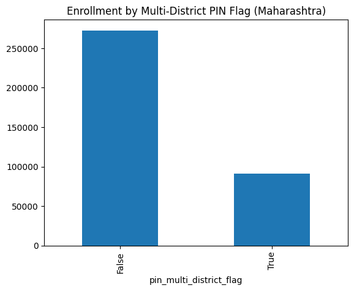

```python
df_Maharashtra.groupby('pin_multi_district_flag')['total_enrollment'].sum().plot(
    kind='bar'
)
plt.title('Enrollment by Multi-District PIN Flag (Maharashtra)')
plt.show()
```

```python
# Aggregate Maharashtra enrollment data at the district level by summing enrollments
# across different age groups (0–5, 5–17, and 18+).
df_maharashtra_dist_level = df_Maharashtra_cleaned.groupby('district_clean')[
    ['age_0_5', 'age_5_17', 'age_18_greater']
].sum()

# Compute total enrollment for each district by adding all age-group enrollments
df_maharashtra_dist_level['total_enrollment'] = (
    df_maharashtra_dist_level['age_0_5'] +
    df_maharashtra_dist_level['age_5_17'] +
    df_maharashtra_dist_level['age_18_greater']
)
```

```python
df_maharashtra_dist_level.shape
```

[output not shown]

```python
df_maharashtra_dist_level
```

| district_clean | age_0_5 | age_5_17 | age_18_greater | total_enrollment |
| --- | --- | --- | --- | --- |
| Ahmednagar | 9697 | 2514 | 153 | 12364 |
| Akola | 3922 | 691 | 49 | 4662 |
| Amravati | 5700 | 1009 | 107 | 6816 |
| Beed | 7823 | 2569 | 270 | 10662 |
| Bhandara | 1801 | 55 | 6 | 1862 |
| Buldhana | 6713 | 1189 | 141 | 8043 |
| Chandrapur | 3965 | 371 | 86 | 4422 |
| Chatrapati Sambhaji Nagar | 114 | 81 | 16 | 211 |
| Chhatrapati Sambhajinagar | 12602 | 5162 | 375 | 18139 |
| Dharashiv | 3270 | 721 | 37 | 4028 |
| Dhule | 7191 | 4804 | 516 | 12511 |
| Gadchiroli | 2054 | 265 | 22 | 2341 |
| Gondia | 2799 | 109 | 6 | 2914 |
| Hingoli | 6327 | 1449 | 370 | 8146 |
| Jalgaon | 10346 | 2560 | 223 | 13129 |
| Jalna | 4564 | 930 | 18 | 5512 |
| Kolhapur | 6324 | 970 | 69 | 7363 |
| Latur | 5709 | 1605 | 148 | 7462 |
| Mumbai City | 12705 | 4249 | 236 | 17190 |
| Mumbai Suburban | 12320 | 4882 | 779 | 17981 |
| Mumbai( Sub Urban ) | 334 | 77 | 0 | 411 |
| Nagpur | 9943 | 1487 | 229 | 11659 |
| Nanded | 9010 | 2427 | 330 | 11767 |
| Nandurbar | 7688 | 2652 | 237 | 10577 |
| Nashik | 15984 | 5731 | 304 | 22019 |
| Palghar | 7220 | 3157 | 162 | 10539 |
| Parbhani | 4961 | 1000 | 198 | 6159 |
| Pune | 23622 | 6404 | 1122 | 31148 |
| Raigad | 2548 | 730 | 102 | 3380 |
| Raigarh | 4318 | 800 | 1 | 5119 |
| Raigarh(MH) | 70 | 15 | 0 | 85 |
| Ratnagiri | 2267 | 213 | 32 | 2512 |
| Sangli | 5502 | 1781 | 132 | 7415 |
| Satara | 5005 | 707 | 153 | 5865 |
| Sindhudurg | 1088 | 55 | 20 | 1163 |
| Solapur | 9324 | 2454 | 249 | 12027 |
| Thane | 28692 | 13492 | 958 | 43142 |
| Wardha | 1800 | 83 | 5 | 1888 |
| Washim | 3000 | 299 | 44 | 3343 |
| Yavatmal | 5952 | 1320 | 198 | 7470 |